# Bike Sharing Analysis

Bike Sharing Analysis N Plaunov 2024-01-09

## Business task

#### Recommendations, based on discovered facts

- **Limit duration of a single ride for non-members**, without affecting members trips duration
- Minimize impact of such policy change by **carefully choosing duration limit**  
  *Suggestion: set maximum duration of the trip for casual riders at or about average time they spend on a trip*
- Considering that there is a small number of bike station, preferred by casual riders, **organize campaign** in the vicinity of those stations, explaining advantages of the annual subscription
- Aforementioned changes should create conditions that make membership more attractive

#### *Technical details of the data analysis could be found below*

#### Preparing Environment and Loading Data

##### *Loading and Normalizing Data Across Two Data Sources*

- Reading data from CSVs …
- Changing column names to match between two data sources …
- Merging data from two data sources …
- Adding calculated columns for summaries …

#### *Performing Data Cleanup and Preparing Data for Graphs*

- Removing trips that have negative duration …
- Removing trips that last more than 1 day …
- Grouping and summarizing data to use in graphs …

#### *Presenting Data Facts*

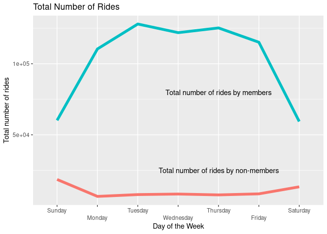

As could be seen from the graph above, casual riders are mostly ride during weekends, while member riders predominantly ride during workdays, which is not surprising. And one can also see that number of rides, ridden by members is significantly larger than for casual riders.

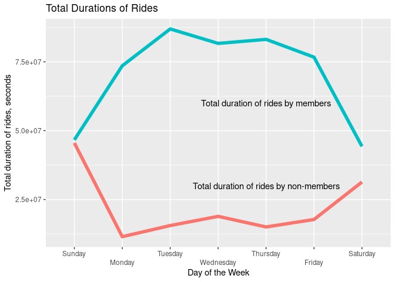

But when we look at the total rides duration for two categories of riders, we can see that despite smaller number of trips, non-members are spending on the road comparable time to the members.

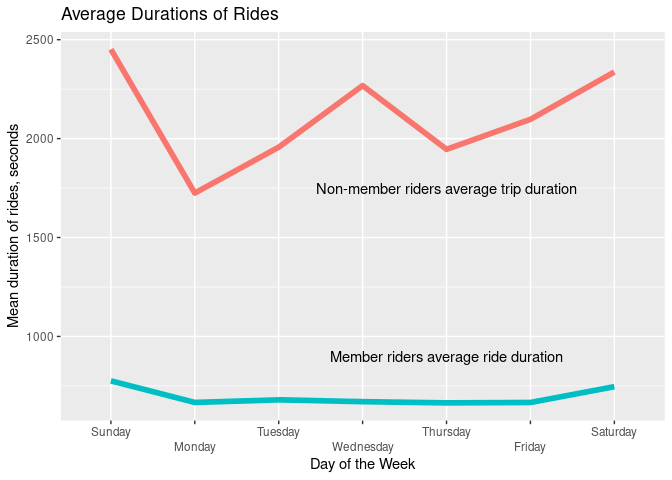

As data for the year of 2020 includes latitude and longitude of each bike station, I used that data to extrapolate to the year of 2019 that allowed me to create maps of the most popular stations for subscribed and non-subscribed travelers.

#### Map of the trips starting stations for **casual** riders

[interactive chart not shown]

#### Map of the trips starting stations for **member** riders

[interactive chart not shown]

### Detailed Recommendations

Considering that casual riders are spending so much time on the bikes and probably are not forced in any way to shorten those rides, it seems reasonable to **create conditions, limiting casual bike trips**, especially during weekends, while members could continue using bikes for as long as they need. Creating such inconvenience for the casual riders should create additional argument for them to consider buying membership. **To avoid significant dissatisfaction by the trip time shortening**, it could be recommended to **set such limit close to their average ride lengths** (i.e., ~2000 seconds or 33:20 minutes.)

As could be seen from two previous maps, **casual riders prefer a handful of stations** to start their trips, while bike sharing members usually use bikes to commute to the jobs that are distributed around the city. Based on this information, it could be suggested to **create membership promotional campaign in vicinity of the bike stations, preferred by casual riders**, explaining new rules and advantages to become members.

##### *Bike Staions, Favored by the Casual Riders*

| Station Name | Number of Rides |
| --- | --- |
| HQ QR | 3556 |
| Streeter Dr & Grand Ave | 2741 |
| Lake Shore Dr & Monroe St | 2727 |
| Shedd Aquarium | 1831 |
| Millennium Park | 1403 |
| Michigan Ave & Oak St | 1017 |
| Michigan Ave & Washington St | 835 |
| Dusable Harbor | 829 |
| Adler Planetarium | 826 |
| Theater on the Lake | 794 |